# Problem-set-3

Question 1.

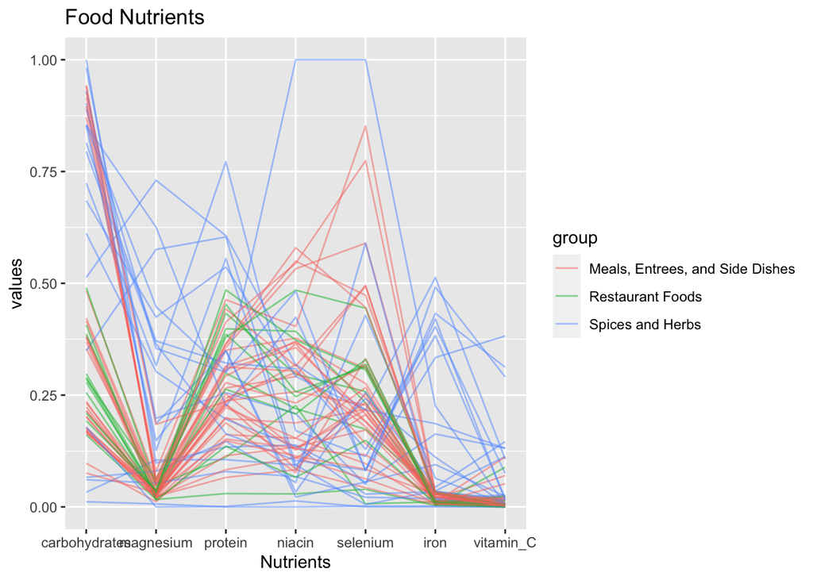

```r
library(GGally)
library(dplyr)
library(EDAWR)
# Load data
data_nutrition <- EDAWR::nutrition

# Subsetting by choosing group as 'Spices and Herbs', 'Restaurant Foods' & 'Meals, Entrees and Side Dishes'
subs_data <- data_nutrition[data_nutrition$group == 'Spices and Herbs' | data_nutrition$group == 'Restaurant Foods' | data_nutrition$group =="Meals, Entrees, and Side Dishes", ]

# Choosing 8 numerical columns
subs_data <- subs_data[c( 'protein', 'carbohydrates', 'selenium', 'iron', 'magnesium', 'niacin', 'vitamin_C', 'group')]

# Taking a random sample of the data (100 rows) to aid interpretability
subs_data <-  subs_data[sample(nrow(subs_data), 100), ]


# Reordering columns
subs_data <- subs_data[,c(8, 2, 5, 1, 6, 3, 4, 7)]


# Creating parallel coordinate, removing the group column, and grouping by it
gq1a <- ggparcoord(subs_data,
                columns=c(2:ncol(subs_data)),
                groupColumn = "group",
                alphaLines = 0.5,
                title = "Food Nutrients",
                scale="uniminmax",
                splineFactor = 1) + ylab('values') + xlab('Nutrients')
gq1a
```

The 3 groups we have chosen are: 1) ‘Spices and Herbs’ 2) ‘Restaurant Foods’ 3) ‘Meals, Entrees and Side Dishes’

We chose a sample size of 100, as this allows us to understand the plots, and have a sample size large enough to give us a representative plot.

Parameter Discussion: Scale: 1) ‘std’ was not chosen because it some columns such as ‘iron’ and ‘magnesium’ have values too close to the mean and thus doing std scaling results in loss of interpretability as the points are packed too close to one another. 2 2) ‘robust’ scaling caused issues with the ‘iron’ and ‘vitamin C’ columns, blowing up certain values. This resulted in a plot where the other columns were packed extremely close. 3) ‘uniminmax’ scaling gave the best compromise as it scales all values between 0 and 1 in a univariate fashion, resulting in good readability of the plot. 4) ‘globalminmax’ scales by the global minimum and maximum across all variables and thus was not ideal as ‘magnesium’ columns values were much higher than the other variables. 5) ‘center’ and ‘centerObs’ caused negative values for the variables, and thus was not chosen.

alphaLines: this dictates the alpha parameter for the lines. Due to the large number of points (100) chosen in our sample, we found that an alpha value between 0.4-0.6 worked best.

```r
library(parcoords)
library(d3r)
# Fixing the parcoords bug of not plotting if the first row has NA by:
# Step 1: Finding the first row which has no NAs in any column
# Step 2: Swapping that row with the first row, and storing modified dataframe in subs_data_aug
first_true_ind <- min(which(complete.cases(subs_data)==TRUE))
subs_data_aug <- subs_data[c(first_true_ind, 3:first_true_ind-1, 1, first_true_ind+1:(nrow(subs_data)-first_true_ind)), ]

# Using parcoords package to create interactive plot
parcoords::parcoords(subs_data_aug,
                     rownames = FALSE,
                     reorderable = TRUE,
                     brushMode="1D-axes",
                     alphaOnBrushed=0.1,
                     color= list(colorBy="group",
                                 colorScale = "scaleOrdinal",
                                 colorScheme = "schemeCategory10"),
                     withD3 = TRUE,
                     width=1000,
                     height=500,
                     margin=150)
```

[interactive chart not shown]

Ordering of columns: We chose this reordering based on the correlations between different nutrients. We have also chosen an alphaOnBrushed value of 0.1, as we can see the regions which have not been selected as well, so we know where the lines are at all times.

Through our plots, we have found the following distinct features: Clusters: The ‘spices and herbs’ group seems to have high carbohydrates content. This group also has the highest magnesium content. This group also has the highest iron content in comparison to the other two groups. Some items of this group also has very high vitamin C content. ‘Restaurant foods’ and ‘meats, entrees and side dishes’ also have very low vitamin C, iron and comparitively lower magnesium content as well.

There also are correlations between the (iron, magnesium), (megnesium, carbohydrates), and (protein, magnesium) pairs. However, these correlations are slightly weaker that protein, niacin.